# Decision Tree Classifier in R

Salman Virani

```r
library(readr)
library(dplyr)
library(keras)
library(caret)
library(rpart)
library(rpart.plot)

source("./functions/train_val_test.R")
```

# 1 Data Understanding

We will work on spam emails.

## 1.1 Data Import

```r
# if file does not exist, download it first
file_path <- "./data/spam.csv"
if (!file.exists(file_path)) {
  dir.create("./data")
  url <- "https://archive.ics.uci.edu/ml/machine-learning-databases/spambase/spambase.data"
  download.file(url = url,
                destfile = file_path)
}
```

Import the file to an object called “spam”.

```r
spam <- read_csv("./data/spam.csv")
```

[output not shown]

# 2 Data Preparation

## 2.1 Column Names

Assign the column names correctly.

```r
col_names_to_set <- c("word_freq_make","word_freq_address","word_freq_all","word_freq_3d","word_freq_our","word_freq_over","word_freq_remove","word_freq_internet","word_freq_order","word_freq_mail","word_freq_receive","word_freq_will","word_freq_people","word_freq_report","word_freq_addresses","word_freq_free","word_freq_business","word_freq_email","word_freq_you","word_freq_credit","word_freq_your","word_freq_font","word_freq_000","word_freq_money","word_freq_hp","word_freq_hpl","word_freq_george","word_freq_650","word_freq_lab","word_freq_labs","word_freq_telnet","word_freq_857","word_freq_data","word_freq_415","word_freq_85","word_freq_technology","word_freq_1999","word_freq_parts","word_freq_pm","word_freq_direct","word_freq_cs","word_freq_meeting","word_freq_original","word_freq_project","word_freq_re","word_freq_edu","word_freq_table","word_freq_conference","char_freq_;","char_freq_(","char_freq_[","char_freq_!","char_freq_$","char_freq_#","capital_run_length_average","capital_run_length_longest","capital_run_length_total", "target"
)
colnames(spam) <- col_names_to_set
```

Check the summary of the data to see if there are missing values. Are there any missing?

```r
sum(is.na(spam))
```

```
## [1] 0
```

```r
# There are no missing values
```

Transform the target variable to factors.

```r
spam$target <- as.factor(spam$target)
```

## 2.2 Train / Validation / Test Split

Split the data into train, validation, and test data. Use splitting ratios of 80% training, 20% validation. Multi-Assignment Operator from keras has been used here.

```r
c(train, val, test) %<-% train_val_test_split(spam, 0.8, 0.2, 0)
```

# 3 Modeling

## 3.1 Model Creation

Create a decision tree model for target-variable. Take all other parameters into account.

```r
model_decision_tree <- rpart(target~., data = train)
```

## 3.2 Visualisation

Create a visualisation which shows the decision tree.

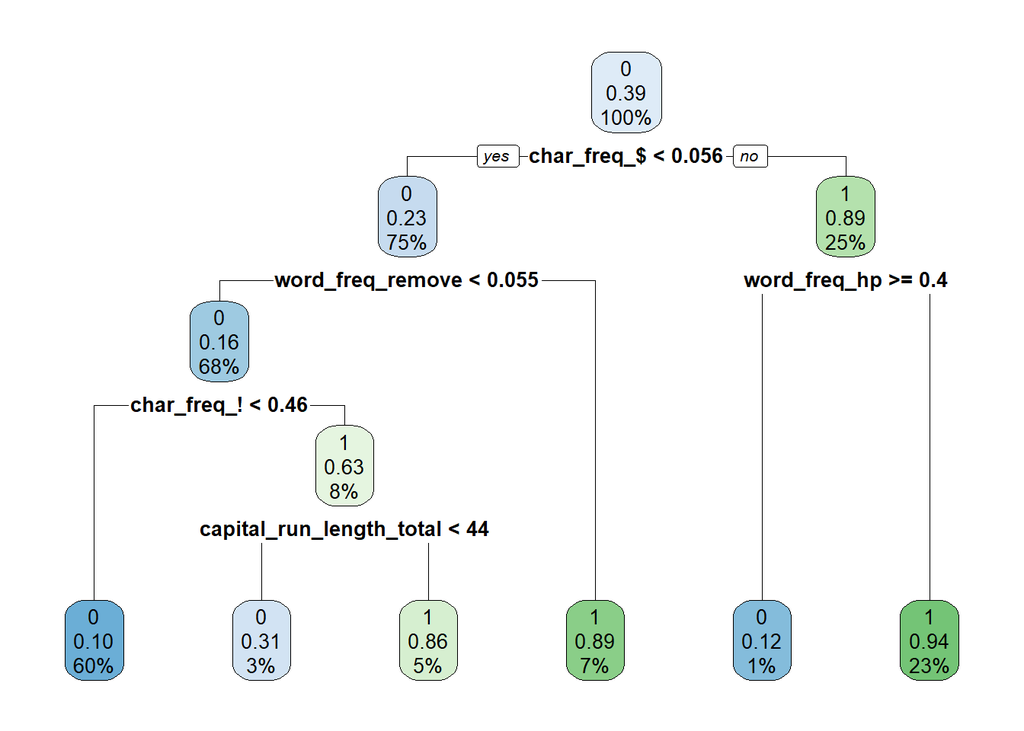

```r
rpart.plot(x = model_decision_tree)
```

# 4 Predictions

Create predictions for train, and validation data. These will be probabilities.

```r
train$target_pred <- predict(model_decision_tree, newdata = train)[,2]
val$target_pred <- predict(model_decision_tree, newdata = val)[,2]
```

Based on probablitites we want to derive class predictions. Please use of threshold of 0.5 for assignment of classes.

```r
train$target_pred_class <- ifelse(train$target_pred > 0.5, 1, 0) %>%
  as.factor()
val$target_pred_class <- ifelse(val$target_pred > 0.5, 1, 0) %>% as.factor()
```

# 5 Model Performance

We will compare our classifier to the baseline classifier.

## 5.1 Baseline Classifier

Please calculate the baseline classifier (assignment to most frequent class).

```r
table(train$target)[1] / length(train$target) * 100
```

```
##        0
## 60.81522
```

## 5.2 Confusion Matrix

Calculate a confusion matrix for Training Data:

```r
conf_mat_train <- table(Predicted = train$target_pred_class, Actual = train$target)
conf_mat_train
```

```
##          Actual
## Predicted    0    1
##         0 2132  264
##         1  106 1178
```

Calculate a confusion matrix for Validation Data:

```r
conf_mat_val <- table(Predicted = val$target_pred_class, Actual = val$target)
conf_mat_val
```

```
##          Actual
## Predicted   0   1
##         0 528  81
##         1  22 289
```

Calculate the Accuracy from the confusion matrix (for training and validation data).

```r
confusionMatrix(conf_mat_train)
```

```
## Confusion Matrix and Statistics
##
##          Actual
## Predicted    0    1
##         0 2132  264
##         1  106 1178
##
##                Accuracy : 0.8995
##                  95% CI : (0.8893, 0.909)
##     No Information Rate : 0.6082
##     P-Value [Acc > NIR] : < 2.2e-16
##
##                   Kappa : 0.7849
##
##  Mcnemar's Test P-Value : 3.294e-16
##
##             Sensitivity : 0.9526
##             Specificity : 0.8169
##          Pos Pred Value : 0.8898
##          Neg Pred Value : 0.9174
##              Prevalence : 0.6082
##          Detection Rate : 0.5793
##    Detection Prevalence : 0.6511
##       Balanced Accuracy : 0.8848
##
##        'Positive' Class : 0
##
```

```r
confusionMatrix(conf_mat_val)
```

```
## Confusion Matrix and Statistics
##
##          Actual
## Predicted   0   1
##         0 528  81
##         1  22 289
##
##                Accuracy : 0.888
##                  95% CI : (0.8659, 0.9077)
##     No Information Rate : 0.5978
##     P-Value [Acc > NIR] : < 2.2e-16
##
##                   Kappa : 0.7609
##
##  Mcnemar's Test P-Value : 1.098e-08
##
##             Sensitivity : 0.9600
##             Specificity : 0.7811
##          Pos Pred Value : 0.8670
##          Neg Pred Value : 0.9293
##              Prevalence : 0.5978
##          Detection Rate : 0.5739
##    Detection Prevalence : 0.6620
##       Balanced Accuracy : 0.8705
##
##        'Positive' Class : 0
##
```

**Is our classifier superior to baseline classifier?**

Yes, both the training and validation accuracy is very good.

Lastly, lets thank the UCI Machine Learning Repository from where we got the data.